# Práctica 4: Algoritmos genéticos

Autor: Alfonso Porras Pérez

Fecha: 14/12/2023

# Apartado 0. Código auxiliar para la ejecución del notebook

En esta sección se implementan funciones y variables necesarias para la correcta ejecución del código.

He decidido incluir esta sección para mejorar la limpieza y resaltar el código importante en el resto del informe.

```python
from Datos import Datos
from AlgoritmoGenetico import AlgoritmoGenetico
from EstrategiaParticionado import ValidacionCruzada
import numpy as np
import pickle
import matplotlib.pyplot as plt

dataset_xor = Datos(nombreFichero='datasets/xor.csv',
                    one_hot_encode=True,
                    nominalAtributos=[True, True, True])
dataset_titanic = Datos(nombreFichero='datasets/titanic.csv',
                        one_hot_encode=True,
                        nominalAtributos=[True, True, True, True])

particionador = ValidacionCruzada(numeroParticiones=5)

def evaluar_ag(n_poblacion, max_reglas, epoch, prob_mutacion,
               dataset):

    ag = AlgoritmoGenetico(n_poblacion=n_poblacion,
                       max_reglas=max_reglas,
                       epoch=epoch,
                       prob_mutacion=prob_mutacion,
                       verbose=True)

    particiones = particionador.creaParticiones(dataset.datos)

    particion = particiones[0]  # Escojo particiones arbitrarias para esta prueba
    ag.entrenamiento(dataset.extraeDatos(particion.indicesTrain),
                    dataset.nominalAtributos,
                    dataset.diccionarios)

    predicciones = ag.clasifica(dataset.extraeDatos(particion.indicesTest),
                            dataset.nominalAtributos,
                            dataset.diccionarios)

    error = ag.error(dataset.extraeDatos(particion.indicesTest),
                     predicciones)

    return ag, error

def generar_graficos_evolucion_fitness(ag):
    _, axs = plt.subplots(1, 2, figsize=(10, 4))

    axs[0].set_title('Evolución del fitness medio de la población')
    axs[0].set_xlabel('Generación')
    axs[0].set_ylabel('Fitness')
    axs[0].plot(ag.evol_fitness_medio)

    axs[1].set_title('Evolución del fitness del mejor individuo')
    axs[1].set_xlabel('Generación')
    axs[1].set_ylabel('Fitness')
    axs[1].plot(ag.evol_fitness_mejor)

    plt.tight_layout()
    plt.show()
```

# Apartado 1. Detalles de la implementación

Para la implementación del algoritmo he seguido el esquema visto en teoría, a saber:

1. Inicialización de la población *P* (primera generación).
2. Mientras no se cumpla el criterio de terminación:
   1. S = Selección de progenitores(P) // Seleccionar progenitores para crear descendencia
   2. S = Recombinación(S) // Recombinar para generar descendencia
   3. S = Mutacion(S) // Mutar para generar descendencia
   4. P = Seleccion de supervivientes(P, S) //Seleccionar nueva generación *P*, de acuerdo a la función de fitness.
3. Return best(*P*)

El código se encuentra en el fichero `AlgoritmoGenetico.py`. Como ya incluye comentarios, aquí solo indico detalles más generales del funcionamiento de este.

## Comentarios generales

- **Reglas permitidas**: para conseguir una base de reglas más específica, se evitan las que tengan hipótesis a todo 1 o 0. Sin embargo, solo lo compruebo al crear la población inicial. Me habría gustado implementarlo también tras cruzar o mutar los individuos, pero esto añade una carga computacional muy elevada.
- **Selección de supervivientes**: se realiza una renovación completa de los individuos teniendo en cuenta la proporción de elitismo y los descendientes resultantes de la recombinación y mutación.

## `Datos.py`

Para implementar el one-hot encoding ha sido necesario modificar la clase `Datos`. Ahora, el constructor cuenta con dos parámetros nuevos:

- `one_hot_encode`: booleano, para indicar si se quiere realizar la codificación.
- `nominalAtributos`: ahora, puedes indicar el atributo `nominalAtributos` si quieres que se asuma uno por defecto para cada columna del archivo csv. Si es `None`, se calcula automáticamente, por lo que este fichero de `Datos.py` sigue estando soportado para las prácticas anteriores.

## Método `_predicciones_individuo`

La lógica para determinar si una regla de un individuo ha sido activada se encapsula en el método `_predicciones_individuo`.

El principal problema que he encontrado en esta práctica ha sido el rendimiento del algoritmo que se nos propuso en clase: para cada instancia del dataset hay que iterar por cada regla del individuo, evaluar la lógica y realizar la votación. En las primeras pruebas que hice, implementé este esquema "directamente", dando como resultado muchos bucles anidados que me daban tiempos de ejecución altísimos.

Por ello, he decidido pensar un algoritmo para poder aprovechar la librería `numpy`, ya que esta permite trabajar con matrices muy eficientemente. El siguiente diagrama muestra en detalle el comportamiento del algoritmo para una regla dada y la matriz de datos:

[figure not shown]

1. Se utiliza el método `_agrupar_matriz` para generar una lista de submatrices, de manera que se separen de acuerdo a las columnas de cada atributo. En el ejemplo visto, los atributos tienen dos columnas para representar los valores posibles, por lo que se divide en dos matrices.
2. Iterando por las listas, se realiza un `AND` de la regla con los datos.
3. Se utiliza el método `numpy.any()` sobre las filas de los resultados del apartado anterior. Dicho de otra forma, se comprueba si al menos un valor de un atributo de la regla se cumple en la instancia.
4. Ahora queremos saber si todos los atributos de la regla se activan, por lo que se utiliza `numpy.all()` para comprobar que hay un valor de `True` para **todos** los atributos.
5. Se usa `numpy.where()` para saber los índices que han activado alguna regla en la matriz de datos.
6. Se actualiza la matriz de contadores. Esta la usa el individuo para para implementar la votación de las reglas. Tiene dimensión `len(datos)xn_clases` y lleva la cuenta de las predicciones que dicen las reglas del individuo. Por ejemplo, si una regla dice que la tercera instancia del dataset tiene clase '0', `contador[2][0]` se incrementa en 1.

De esta manera, para que un individuo calcule predicciones sobre las instancias del dataset, va a ejecutar el algoritmo descrito para cada una de sus reglas. Finalmente, consultará la matriz de contadores para resolver la votación.

Como detalle a destacar sobre la votación, en caso de que haya empate se asigna la clase que mayor probabilidad tenga a priori en el conjunto de entrenamiento. Además, en caso de que no se haya activado ninguna regla para una instancia, se le asigna la clase `-1` para que compute como error al calcular el fitness.

Este algortimo, aunque un poco confuso, me ha permitido mejorar mucho el rendimiento del programa. En mi equipo, la versión "tradicional" tarda alrededor de 35 segundos en evaluar 11 generaciones, mientras que la "mejorada" consigue 250 generaciones en menos de 20 segundos.

## Mecanismo de cruce implementado

Como se puede ver en el constructor de `AlgoritmoGenetico`, se permiten 3 modos de cruce:

- `intra`: intra-regla visto en clase. Se escogen aleatoriamente una regla de cada progenitor y un punto de cruce común. Después, se intercambia el material genético.
- `inter`: inter-regla visto en clase. Se escogen dos reglas aleatoriamente de cada progenitor y se intercambian.
- `ambos`: se realiza un `intra` y, sobre las mismas reglas, un `inter`.

Por falta de tiempo, no he implementado añadir o eliminar una regla de los individuos. Sin embargo, el diseño permite incorporar estas funcionalidades eficazmente.

## Mecanismo de mutación implementado

La mutación es estándar aplicada a todas las reglas del individuo.

Como detalle, comentar que el atributo `AlgoritmoGenetico.prob_mutacion` indica la probabilidad con la que un bit se puede cambiar. En caso de que sea `None`, se toma $\frac{1}{len(individuo) \cdot len(regla)}$; es decir, se espera que un bit de alguna de las reglas del individuo sea mutada en cada generación.

De nuevo, me habría gustado implementar y estudiar el efecto de realizar la mutación sólo sobre una de las reglas del individuo, pero me ha sido imposible.

# Apartado 2. Mejores hiperparámetros para los datasets `titanic.csv` y `xor.csv`

En esta sección primero se van a buscar los mejores hiperparámetros para los datasets `titanic.csv` y `xor.csv`.

Como apunte, señalar que para todas las pruebas de esta práctica utilizo Validación Cruzada con 5 particiones en los datos. Esta decisión se debe a que, como hemos visto anteriormente, es el tipo de particionado que proporciona resultados más robustos. Sin embargo, como trabajo a futuro sería interesante estudiar el efecto de modificar el número de particiones o incluso utilizar Validación Simple.

## Cálculo de los mejores hiperparámetros

Como se puede ver en el constructor de `AlgoritmoGenetico`, existen muchas configuraciones posibles. En los experimentos realizados he comprobado que los más significativos son el tamaño de la población (`n_poblacion`) y el número de generaciones (`epoch`). Por ello, voy a organizar las pruebas en dos partes:

1. **`n_poblacion` y `epoch` fijos en valores intermedios**. Así, probaré a ir ajustando los parámetros `max_reglas`, `estrategia_cruce`, `prob_cruce` y `prob_mutacion`, para conseguir los valores más óptimos.
2. **Variación fina de `n_poblacion` y `epoch`**. Como estos son los que más influyen al rendimiento del algoritmo, quiero centrar la mayoría de las pruebas en ajustar estos hiperparámetros. Gracias a los resultados del paso anterior, podré realizar pruebas variando poco a poco el tamaño de la población y el número de generaciones sin tener que volver a estudiar el resto de parámetros.

Además, estoy considerando los umbrales que sugiere el enunciado (proporción de elitismo = 5%, tamaño de la población de 50 y 100, épocas entre 50 y 100 y máximo de 5 reglas por individuo), pero sería interesante como trabajo a futuro (*y tan futuro, porque menudos tiempos de ejecución me han salido!*) probar con otros intervalos.

### Selección de hiperparámetros

#### Dataset `xor.csv`

##### Prueba 1: **`n_poblacion` y `epoch` fijos en valores intermedios**

Veamos el rendimiento del algoritmo genético tomando los valores fijos `n_poblacion = 75` y `epoch = 75` y variando el resto de hiperparámetros

```python
%%time

from itertools import product

opciones_max_reglas = [1, 3, 5]
opciones_estrategia_cruce = ['inter', 'intra', 'ambos']
opciones_prob_cruce = [0.75, 0.85, 0.95]
opciones_prob_mutacion = [None, 0.2, 0.5]

resultados = []
# Producto cartesiano de todas las posibilidades
combinaciones = list(product(opciones_max_reglas,
                             opciones_estrategia_cruce,
                             opciones_prob_cruce,
                             opciones_prob_mutacion))
i = 1   # Para ir escribiendo el progreso
for max_reglas, estrategia_cruce, prob_cruce, prob_mutacion in combinaciones:
    ag = AlgoritmoGenetico(n_poblacion=75,
                           max_reglas=max_reglas,
                           epoch=75,
                           estrategia_cruce=estrategia_cruce,
                           prob_cruce=prob_cruce,
                           prob_mutacion=prob_mutacion,
                           verbose=False)

    errores = ag.validacion(particionado=particionador,
                            dataset=dataset_xor,
                            clasificador=ag)
    error_medio, desviacion = np.mean(errores), np.std(errores)
    resultados.append((max_reglas, estrategia_cruce,
                       prob_cruce, prob_mutacion,
                       error_medio, desviacion))

    print(f"\rPrueba {i}/{len(combinaciones)} completada", end='', flush=True)
    i += 1

print()

# Para evitar ejecutar de nuevo el programa
with open('resultados/xor_hiperparametros_1.pkl', 'wb') as archivo:
    pickle.dump(resultados, archivo)
```

```
Prueba 81/81 completada
CPU times: user 12min 12s, sys: 320 ms, total: 12min 12s
Wall time: 12min 13s
```

Veamos quién ha obtenido el menor error.

```python
with open('resultados/xor_hiperparametros_1.pkl', 'rb') as archivo:
    resultados = pickle.load(archivo)

# Ordenado ascendiente según el error medio
resultados_ordenados = sorted(resultados, key=lambda x: x[4])

print("reglas cruce prob_cruce prob_mut err std")
for resultado in resultados_ordenados:
    print("   ", resultado)
```

```
reglas cruce prob_cruce prob_mut err std
    (3, 'inter', 0.75, None, 0.0, 0.0)
    (3, 'inter', 0.85, None, 0.0, 0.0)
    (3, 'inter', 0.85, 0.2, 0.0, 0.0)
    (3, 'inter', 0.95, None, 0.0, 0.0)
    (3, 'inter', 0.95, 0.2, 0.0, 0.0)
    (3, 'intra', 0.75, None, 0.0, 0.0)
    (3, 'intra', 0.85, None, 0.0, 0.0)
    (3, 'intra', 0.85, 0.2, 0.0, 0.0)
    (3, 'intra', 0.85, 0.5, 0.0, 0.0)
    (3, 'intra', 0.95, None, 0.0, 0.0)
    (3, 'intra', 0.95, 0.2, 0.0, 0.0)
    (3, 'ambos', 0.75, None, 0.0, 0.0)
    (3, 'ambos', 0.75, 0.2, 0.0, 0.0)
    (3, 'ambos', 0.85, None, 0.0, 0.0)
    (3, 'ambos', 0.95, None, 0.0, 0.0)
    (5, 'inter', 0.75, None, 0.0, 0.0)
    (5, 'inter', 0.75, 0.2, 0.0, 0.0)
    (5, 'inter', 0.75, 0.5, 0.0, 0.0)
    (5, 'inter', 0.85, None, 0.0, 0.0)
    (5, 'inter', 0.85, 0.2, 0.0, 0.0)
    (5, 'inter', 0.85, 0.5, 0.0, 0.0)
    (5, 'inter', 0.95, None, 0.0, 0.0)
    (5, 'inter', 0.95, 0.2, 0.0, 0.0)
    (5, 'inter', 0.95, 0.5, 0.0, 0.0)
    (5, 'intra', 0.75, None, 0.0, 0.0)
    (5, 'intra', 0.75, 0.2, 0.0, 0.0)
    (5, 'intra', 0.75, 0.5, 0.0, 0.0)
    (5, 'intra', 0.85, None, 0.0, 0.0)
    (5, 'intra', 0.85, 0.2, 0.0, 0.0)
    (5, 'intra', 0.85, 0.5, 0.0, 0.0)
    (5, 'intra', 0.95, None, 0.0, 0.0)
    (5, 'intra', 0.95, 0.2, 0.0, 0.0)
    (5, 'intra', 0.95, 0.5, 0.0, 0.0)
    (5, 'ambos', 0.75, None, 0.0, 0.0)
    (5, 'ambos', 0.75, 0.2, 0.0, 0.0)
    (5, 'ambos', 0.75, 0.5, 0.0, 0.0)
    (5, 'ambos', 0.85, None, 0.0, 0.0)
    (5, 'ambos', 0.85, 0.2, 0.0, 0.0)
    (5, 'ambos', 0.85, 0.5, 0.0, 0.0)
```

[output cut: 27 more lines]

```
    (1, 'ambos', 0.95, 0.2, 0.5349999999999999, 0.02893959225697556)
    (1, 'inter', 0.85, 0.5, 0.535, 0.032977264895682305)
    (1, 'ambos', 0.85, None, 0.5399999999999999, 0.01837117307087381)
    (1, 'inter', 0.75, 0.2, 0.54, 0.024238399287081637)
    (1, 'intra', 0.95, 0.5, 0.54, 0.02783882181415014)
    (1, 'inter', 0.75, None, 0.5449999999999999, 0.03921096785339533)
    (1, 'intra', 0.75, None, 0.545, 0.02573907535246749)
    (1, 'intra', 0.75, 0.2, 0.545, 0.03758324094593228)
    (1, 'intra', 0.85, 0.2, 0.545, 0.03221024681681281)
    (1, 'ambos', 0.95, None, 0.55, 0.03535533905932736)
    (1, 'inter', 0.95, 0.5, 0.5549999999999999, 0.03588175023601831)
    (1, 'inter', 0.95, 0.2, 0.5599999999999999, 0.019999999999999997)
    (1, 'intra', 0.75, 0.5, 0.5650000000000001, 0.036571847095819496)
    (1, 'inter', 0.75, 0.5, 0.58, 0.04227883631321939)
    (1, 'inter', 0.85, None, 0.5900000000000001, 0.031024184114977156)
```

Como se puede ver, hay muchas combinaciones que consiguen un **100% de acierto**.

Cabe señalar que todas las opciones con un máximo de 5 reglas consiguen ese resultado. Por el contrario, ninguna de ellas lo ha conseguido con solo 1 regla, ya que es imposible encapsular la lógica de una puerta `xor` con el sistema que hemos establecido para esta práctica.

Además, vemos que cuando el máximo de reglas es 3, los resultados están más repartidos. Ahora la cuestión es si esto es culpa de `estrategia_cruce`, `prob_cruce` o `prob_mutación`. Para ello, el siguiente script va a separar las instancias con `max_reglas = 3` en dos grupos: las que han conseguido un resultado perfecto (100% de acierto) y las que no. De esta manera, podremos ver si existe algún hiperparámetro que esté correlacionado con esta división.

```python
# Resultados anteriores filtrados a los que tienen 'max_reglas' = 3
resultados_3_reglas = [resultado for resultado in resultados if resultado[0] == 3]

# De los anteriores, los que han conseguido un 100% de acierto
resultados_3_reglas_perfectos = [resultado for resultado in resultados_3_reglas if resultado[4] == 0]
# De los anteriores, los que tienen algo de error
resultados_3_reglas_no_perfectos = [resultado for resultado in resultados_3_reglas if resultado not in resultados_3_reglas_perfectos]

# A partir de aquíel  código itera por cada instancia de 'resultados_3_reglas_no_perfectos'.
# De esta forma, va a buscar si hay algúna instancia de 'resultados_3_reglas_perfectos'
# que tenga los mismos parámetros para el cruce o la mutación.

# Estas listas deben interpretarse como: 'coincidencias_cruce[i]' indica el número de
# instancias en 'resultados_3_reglas_perfectos' que tienen mismos parámetros para
# el cruce que la instancia 'i' de 'resultados_3_reglas_no_perfectos'.
coincidencias_cruce = np.zeros(len(resultados_3_reglas_no_perfectos))
coincidencias_mutacion = np.zeros(len(resultados_3_reglas_no_perfectos))
i = 0
for resultado in resultados_3_reglas_no_perfectos:
    for resultado_perfecto in resultados_3_reglas_perfectos:
        # como 'estrategia_cruce' y 'prob_cruce' están relacionados
        # directamente, busco que coincidan ambos.
        if resultado[1] == resultado_perfecto[1] and \
            resultado[2] == resultado_perfecto[2]:
            coincidencias_cruce[i] += 1

        if resultado[3] == resultado[3]:
            coincidencias_mutacion[i] += 1
    i += 1

print("# de combinaciones con max_reglas = 3: ", len(resultados_3_reglas))
print("\t- # con 100% de acierto:", len(resultados_3_reglas_perfectos))
print("\t- # con algo de error:", len(resultados_3_reglas_no_perfectos))
print("\t\t- coincidencias en parámetros de cruce: ", coincidencias_cruce)
print("\t\t- coincidencias en parámetros de mutación: ", coincidencias_cruce)
```

```
# de combinaciones con max_reglas = 3:  27
	- # con 100% de acierto: 15
	- # con algo de error: 12
		- coincidencias en parámetros de cruce:  [1. 1. 2. 2. 1. 1. 2. 2. 1. 1. 1. 1.]
		- coincidencias en parámetros de mutación:  [1. 1. 2. 2. 1. 1. 2. 2. 1. 1. 1. 1.]
```

En conclusión, para el dataset `xor.csv` **yo escogería un número máximo de reglas de 5**, ya que es el que garantiza un 100% de acierto **con 75 hijos y 75 iteraciones**. En cuanto al resto de hiperparámetros, no veo que ninguno sea especialmente relevante para aumentar la precisión en este conjunto de datos.

##### Prueba 2: **Variación fina de `n_poblacion` y `epoch`**

Aunque ya hemos conseguido un 100% de acierto, me parece interesante estudiar si podemos conseguirlo con menos individuos o iteraciones:

```python
%%time

from itertools import product

opciones_n_poblacion = [25, 50, 75, 100]
opciones_epoch = [25, 50, 75, 100]

resultados = []
# Producto cartesiano de todas las posibilidades
combinaciones = list(product(opciones_n_poblacion,
                             opciones_epoch))
i = 1   # Para ir escribiendo el progreso
for n_poblacion, epoch in combinaciones:
    ag = AlgoritmoGenetico(n_poblacion=n_poblacion,
                           max_reglas=5,
                           epoch=epoch,
                           estrategia_cruce='ambos',
                           prob_cruce=0.75,
                           prob_mutacion=None,
                           verbose=False)

    errores = ag.validacion(particionado=particionador,
                            dataset=dataset_xor,
                            clasificador=ag)
    error_medio, desviacion = np.mean(errores), np.std(errores)
    resultados.append((n_poblacion, epoch, error_medio, desviacion))

    print(f"\rPrueba {i}/{len(combinaciones)} completada", end='', flush=True)
    i += 1

print()

# Para evitar ejecutar de nuevo el programa
with open('resultados/xor_hiperparametros_2.pkl', 'wb') as archivo:
    pickle.dump(resultados, archivo)
```

```
Prueba 16/16 completada
CPU times: user 1min 38s, sys: 36 ms, total: 1min 38s
Wall time: 1min 38s
```

```python
with open('resultados/xor_hiperparametros_2.pkl', 'rb') as archivo:
    resultados = pickle.load(archivo)


# Ordenado ascendiente según el error medio
resultados_ordenados = sorted(resultados, key=lambda x: x[2])

print("n_pob epoch err std")
for resultado in resultados_ordenados:
    print("  ", resultado)
```

```
n_pob epoch err std
   (25, 50, 0.0, 0.0)
   (25, 75, 0.0, 0.0)
   (25, 100, 0.0, 0.0)
   (50, 50, 0.0, 0.0)
   (50, 75, 0.0, 0.0)
   (50, 100, 0.0, 0.0)
   (75, 50, 0.0, 0.0)
   (75, 75, 0.0, 0.0)
   (75, 100, 0.0, 0.0)
   (100, 25, 0.0, 0.0)
   (100, 50, 0.0, 0.0)
   (100, 75, 0.0, 0.0)
   (100, 100, 0.0, 0.0)
   (75, 25, 0.052500000000000005, 0.10500000000000001)
   (50, 25, 0.06, 0.12000000000000001)
   (25, 25, 0.17250000000000001, 0.14173037783058368)
```

Como se puede ver, las únicas instancias que no han conseguido un 100% de acierto tienen en común que solo se realizan 25 generaciones. Es decir, **es más importante tener un número de épocas alto que el tamaño de la población escogida**.

Cabe destacar que, cerca de la mitad de la lista, está el caso de `n_poblacion = 100` y `epoch = 25`, el cual sí que tiene un 0% de error. Es decir, el algoritmo ha sido capaz de compensar la falta de generaciones con muchos individuos.

En conclusión, para el dataset `xor.csv` recomiendo los siguientes hiperparámetros:

- `max_reglas = 5`
- `epoch ≥ 50`
- Valores arbitrarios para el resto

#### Dataset `titanic.csv`

##### Prueba 1: **`n_poblacion` y `epoch` fijos en valores intermedios**

```python
%%time

from itertools import product

opciones_max_reglas = [1, 3, 5]
opciones_estrategia_cruce = ['inter', 'intra', 'ambos']
opciones_prob_cruce = [0.75, 0.85, 0.95]
opciones_prob_mutacion = [None, 0.2, 0.5]

resultados = []
# Producto cartesiano de todas las posibilidades
combinaciones = list(product(opciones_max_reglas,
                             opciones_estrategia_cruce,
                             opciones_prob_cruce,
                             opciones_prob_mutacion))
i = 1   # Para ir escribiendo el progreso
for max_reglas, estrategia_cruce, prob_cruce, prob_mutacion in combinaciones:
    ag = AlgoritmoGenetico(n_poblacion=75,
                           max_reglas=max_reglas,
                           epoch=75,
                           estrategia_cruce=estrategia_cruce,
                           prob_cruce=prob_cruce,
                           prob_mutacion=prob_mutacion,
                           verbose=False)

    errores = ag.validacion(particionado=particionador,
                            dataset=dataset_titanic,
                            clasificador=ag)
    error_medio, desviacion = np.mean(errores), np.std(errores)
    resultados.append((max_reglas, estrategia_cruce,
                       prob_cruce, prob_mutacion,
                       error_medio, desviacion))

    print(f"\rPrueba {i}/{len(combinaciones)} completada", end='', flush=True)
    i += 1

print()

# Para evitar ejecutar de nuevo el programa
with open('resultados/titanic_hiperparametros_1.pkl', 'wb') as archivo:
    pickle.dump(resultados, archivo)
```

```
Prueba 81/81 completada
CPU times: user 43min 39s, sys: 184 ms, total: 43min 40s
Wall time: 43min 40s
```

Veamos los resultados ordenados ascendientemente por error medio:

```python
with open('resultados/titanic_hiperparametros_1.pkl', 'rb') as archivo:
    resultados = pickle.load(archivo)


# Ordenado ascendiente según el error medio
resultados_ordenados = sorted(resultados, key=lambda x: x[4])

print("reglas cruce prob_cruce prob_mut err std")
for resultado in resultados_ordenados:
    print("   ", resultado)
```

```
reglas cruce prob_cruce prob_mut err std
    (5, 'inter', 0.75, None, 0.20838915470494418, 0.027462910761291922)
    (5, 'inter', 0.95, None, 0.21508316245158351, 0.01980472872878916)
    (5, 'intra', 0.75, None, 0.21511506037821823, 0.032651959396923294)
    (5, 'ambos', 0.85, None, 0.21797220323536112, 0.03336017117080982)
    (5, 'ambos', 0.95, None, 0.21798587377534742, 0.022876448611567766)
    (5, 'intra', 0.95, None, 0.21890635680109366, 0.026059778580209147)
    (3, 'intra', 0.95, None, 0.21988152198678518, 0.02260404300291341)
    (3, 'inter', 0.75, None, 0.2218090681248576, 0.027086650912655573)
    (3, 'intra', 0.85, None, 0.22182729551150607, 0.01596496934686131)
    (3, 'ambos', 0.85, None, 0.2227432216905901, 0.018172190293406484)
    (3, 'ambos', 0.75, None, 0.22559580770107085, 0.022637529981054543)
    (3, 'intra', 0.75, None, 0.22847573479152428, 0.02734339019631378)
    (3, 'inter', 0.85, None, 0.22849851902483484, 0.028195336918564632)
    (5, 'intra', 0.85, None, 0.23038961038961042, 0.028183985722890274)
    (5, 'inter', 0.85, None, 0.23041239462292093, 0.02493573113181781)
    (3, 'inter', 0.95, None, 0.23042150831624517, 0.014916435069092985)
    (5, 'ambos', 0.75, None, 0.2313602187286398, 0.033929123573092065)
    (3, 'ambos', 0.95, None, 0.23708817498291182, 0.020137480327307368)
    (5, 'inter', 0.75, 0.2, 0.2733743449532923, 0.03314167228641143)
    (3, 'inter', 0.75, 0.2, 0.27819548872180444, 0.015105792039984986)
    (5, 'intra', 0.75, 0.2, 0.2810890863522443, 0.03306946038707695)
    (5, 'intra', 0.95, 0.2, 0.28202779676463885, 0.0263864338767618)
    (5, 'inter', 0.85, 0.2, 0.29342902711323765, 0.044053842964036416)
    (3, 'intra', 0.95, 0.2, 0.29530644793802685, 0.06376933667585609)
    (5, 'intra', 0.85, 0.2, 0.3001686033264981, 0.04506335129155815)
    (5, 'ambos', 0.85, 0.2, 0.30308954203691046, 0.06233820795770381)
    (5, 'ambos', 0.75, 0.2, 0.304064707222602, 0.05164811622554654)
    (5, 'inter', 0.95, 0.2, 0.31268626110731373, 0.046989517833613256)
    (3, 'inter', 0.95, 0.2, 0.31738437001594894, 0.02764282493562142)
    (5, 'ambos', 0.95, 0.2, 0.31743905217589424, 0.04070648645634351)
    (3, 'ambos', 0.95, 0.2, 0.3182957393483709, 0.05366990470134875)
    (3, 'inter', 0.85, 0.2, 0.31839598997493734, 0.04841819218879513)
    (3, 'ambos', 0.85, 0.2, 0.3202187286397813, 0.04059598914014366)
    (3, 'intra', 0.75, 0.2, 0.32605149236728187, 0.051908707464736)
    (5, 'ambos', 0.75, 0.5, 0.3260925039872408, 0.06636084399059537)
    (3, 'ambos', 0.75, 0.2, 0.3279152426520847, 0.030936151086281713)
    (5, 'inter', 0.75, 0.5, 0.3307860560492139, 0.025047085616392555)
    (5, 'inter', 0.95, 0.5, 0.33267259056732745, 0.0357698240687383)
    (5, 'inter', 0.85, 0.5, 0.3460742766005924, 0.010946740793411106)
```

[output cut: 27 more lines]

```
    (1, 'intra', 0.75, 0.2, 0.41204830257461833, 0.022956335199969157)
    (1, 'intra', 0.85, 0.2, 0.41397129186602866, 0.01592776901172301)
    (3, 'intra', 0.95, 0.5, 0.41490544543176117, 0.061089777727274974)
    (1, 'intra', 0.95, 0.2, 0.42637047163362957, 0.024358830873638045)
    (3, 'ambos', 0.75, 0.5, 0.4350011392116655, 0.0436346286120073)
    (3, 'intra', 0.75, 0.5, 0.43784005468216, 0.04655403189050159)
    (1, 'ambos', 0.85, 0.5, 0.46077922077922073, 0.0576529704101212)
    (1, 'ambos', 0.95, 0.5, 0.4618045112781955, 0.030807719753705547)
    (1, 'inter', 0.75, 0.5, 0.4676008202323992, 0.06891240426815767)
    (1, 'inter', 0.85, 0.5, 0.470330371383003, 0.05283698269041741)
    (1, 'intra', 0.75, 0.5, 0.4703440419229893, 0.028458248384466013)
    (1, 'intra', 0.95, 0.5, 0.47706083390293913, 0.02529395701543819)
    (1, 'inter', 0.95, 0.5, 0.47990430622009567, 0.051122336417963946)
    (1, 'intra', 0.85, 0.5, 0.4799498746867168, 0.04669667387274572)
    (1, 'ambos', 0.75, 0.5, 0.4894007746639325, 0.06907312361897006)
```

Vamos a analizar los parámetros comunes que mejores resultados han mostrado:

```python
mejores_resultados = resultados_ordenados[:10]

for resultado in mejores_resultados:
    print(resultado)

contadores = {
    "max_reglas": {},
    "estrategia_cruce": {},
    "prob_cruce": {},
    "prob_mutacion": {}
}
for resultado in mejores_resultados:
    contador = contadores["max_reglas"].get(resultado[0])
    if contador is None:
        contadores["max_reglas"].update({resultado[0]: 1})
    else:
        contadores["max_reglas"].update({resultado[0]: contador + 1})

    contador = contadores["estrategia_cruce"].get(resultado[1])
    if contador is None:
        contadores["estrategia_cruce"].update({resultado[1]: 1})
    else:
        contadores["estrategia_cruce"].update({resultado[1]: contador + 1})

    contador = contadores["prob_cruce"].get(resultado[2])
    if contador is None:
        contadores["prob_cruce"].update({resultado[2]: 1})
    else:
        contadores["prob_cruce"].update({resultado[2]: contador + 1})

    contador = contadores["prob_mutacion"].get(resultado[3])
    if contador is None:
        contadores["prob_mutacion"].update({resultado[3]: 1})
    else:
        contadores["prob_mutacion"].update({resultado[3]: contador + 1})


print("\n--- RECUENTO ---")
for clave, valor in contadores.items():
    print(f'{clave}:')
    if isinstance(valor, dict):
        for subclave, subvalor in valor.items():
            print(f'  {subclave}: {subvalor}')
```

```
(5, 'inter', 0.75, None, 0.20838915470494418, 0.027462910761291922)
(5, 'inter', 0.95, None, 0.21508316245158351, 0.01980472872878916)
(5, 'intra', 0.75, None, 0.21511506037821823, 0.032651959396923294)
(5, 'ambos', 0.85, None, 0.21797220323536112, 0.03336017117080982)
(5, 'ambos', 0.95, None, 0.21798587377534742, 0.022876448611567766)
(5, 'intra', 0.95, None, 0.21890635680109366, 0.026059778580209147)
(3, 'intra', 0.95, None, 0.21988152198678518, 0.02260404300291341)
(3, 'inter', 0.75, None, 0.2218090681248576, 0.027086650912655573)
(3, 'intra', 0.85, None, 0.22182729551150607, 0.01596496934686131)
(3, 'ambos', 0.85, None, 0.2227432216905901, 0.018172190293406484)

--- RECUENTO ---
max_reglas:
  5: 6
  3: 4
estrategia_cruce:
  inter: 3
  intra: 4
  ambos: 3
prob_cruce:
  0.75: 3
  0.95: 4
  0.85: 3
prob_mutacion:
  None: 10
```

Se puede ver una tendencencia clara: la mejor probabilidad de mutación ha sido `None`. Como comenté anteriormente, esto es equivalente a $\frac{1}{len(individuo) \cdot len(regla)}$; es decir, se espera que un bit del individuo se modifique por generación.

En cuanto al resto de parámetros, si bien vemos que están más repartidos, los que han conseguido un error más cercano al 21% son los que tienen un máximo de 5 reglas. No he encontrado ninguna correlación para `estrategia_cruce` o `probabilidad de cruce`.

En conclusión, **los modelos que mayor tasa de acierto consiguen para el dataset `titanic.csv` cumplen que `max_reglas = 5` y `prob_mutacion = None`**.

##### Prueba 2: **Variación fina de `n_poblacion` y `epoch`**

```python
%%time

from itertools import product

opciones_n_poblacion = [25, 50, 75, 100]
opciones_epoch = [25, 50, 75, 100]

resultados = []
# Producto cartesiano de todas las posibilidades
combinaciones = list(product(opciones_n_poblacion,
                             opciones_epoch))
i = 1   # Para ir escribiendo el progreso
for n_poblacion, epoch in combinaciones:
    ag = AlgoritmoGenetico(n_poblacion=75,
                           max_reglas=5,
                           epoch=epoch,
                           estrategia_cruce='inter',
                           prob_cruce=0.75,
                           prob_mutacion=None,
                           verbose=False)

    errores = ag.validacion(particionado=particionador,
                            dataset=dataset_titanic,
                            clasificador=ag)
    error_medio, desviacion = np.mean(errores), np.std(errores)
    resultados.append((n_poblacion, epoch, error_medio, desviacion))

    print(f"\rPrueba {i}/{len(combinaciones)} completada", end='', flush=True)
    i += 1

print()

# Para evitar ejecutar de nuevo el programa
with open('resultados/titanic_hiperparametros_2.pkl', 'wb') as archivo:
    pickle.dump(resultados, archivo)
```

```
Prueba 16/16 completada
CPU times: user 10min 6s, sys: 47.9 ms, total: 10min 6s
Wall time: 10min 7s
```

```python
with open('resultados/titanic_hiperparametros_2.pkl', 'rb') as archivo:
    resultados = pickle.load(archivo)


# Ordenado ascendiente según el error medio
resultados_ordenados = sorted(resultados, key=lambda x: x[2])

print("n_pob epoch err std")
for resultado in resultados_ordenados:
    print(resultado)
```

```
n_pob epoch err std
(100, 75, 0.21794030530872638, 0.023196191871237542)
(25, 75, 0.21890635680109366, 0.021000530286823926)
(25, 100, 0.21989063568010936, 0.04129634588030314)
(100, 100, 0.2198997493734336, 0.027838676946884435)
(75, 100, 0.21990886306675778, 0.03300969908819543)
(50, 75, 0.219917976760082, 0.033054381936178025)
(50, 100, 0.222738664843928, 0.015959115344614288)
(100, 50, 0.22277967646388702, 0.0159290856828268)
(75, 75, 0.22370015948963315, 0.03909514825297611)
(75, 50, 0.22658920027341076, 0.021211374776736708)
(25, 50, 0.2351651856915015, 0.019950817675639887)
(50, 50, 0.24092503987240826, 0.047167273313634364)
(25, 25, 0.2438049669628617, 0.017623062319278928)
(50, 25, 0.24853041695146957, 0.02898541353354767)
(75, 25, 0.25622237411711096, 0.031011387529141145)
(100, 25, 0.2648621553884712, 0.03895080576426276)
```

Por hacer la prueba, me pareció interesante ver si aumentando el número de épocas podemos mejorar aún más el algoritmo:

```python
%%time

ag_titanic_1000, error = evaluar_ag(n_poblacion=25,
                                    max_reglas=5,
                                    prob_mutacion=None,
                                    epoch=1000,
                                    dataset=dataset_titanic)

print("error: ", error)
```

```
Generación 6 completadaGeneración 999 completada
==============================
✅ Entrenamiento finalizado.
🏃Evolución del fitness medio de la población: [0.19072879330943845, 0.30953405017921143, 0.37701314217443255, 0.38532855436081237, 0.4255197132616487, 0.40511350059737156, 0.4128554360812426, 0.4355555555555556, 0.4265710872162484, 0.43550776583034645, 0.45672640382317803, 0.4623178016726404, 0.4504…
💪Evolución del mejor fitness de la población: [0.5364396654719236, 0.5710872162485066, 0.5710872162485066, 0.5710872162485066, 0.5710872162485066, 0.5710872162485066, 0.5710872162485066, 0.5818399044205496, 0.5818399044205496, 0.5818399044205496, 0.5902031063321386, 0.5937873357228196, 0.59378733572…
👑Mejor individuo (fitness = 0.81): [[1, 1, 0, 1, 0, 0, 1, 1, 1, 1, 1, 1, 1, 1, 0, 0, 1, 1, 1, 1, 0, 1], [1, 1, 1, 1, 1, 1, 1, 1, 1, 1, 1, 1, 1, 1, 1, 1, 1, 1, 0, 1, 0, 1], [1, 1, 1, 0, 1, 0, 0, 1, 0, 1, 1, 1, 1, 1, 1, 1, 0, 1, 1, 0, 1, 0], [1, 1, 1, 1, 1, 0, 1, 0, 1, 0, 1, 1, 1, 1, 0, 0, 1, 0, 0, 1,…
==============================
error:  0.22488038277511962
CPU times: user 47.6 s, sys: 196 ms, total: 47.8 s
Wall time: 47.7 s
```

No se ha mejorado el error notablemente; es decir, con 100 generaciones es suficiente para minimizar el error. También hay que tener en cuenta que el error puede estar acotado debido al resto de hiperparámetros, concretamente, el máximo de reglas y el tamaño de la población.

Veamos si aumentando estos se consigue algo:

```python
%%time

ag_titanic_1000, error = evaluar_ag(n_poblacion=50,
                                    max_reglas=20,
                                    prob_mutacion=None,
                                    epoch=1000,
                                    dataset=dataset_titanic)

print("error: ", error)
```

```
Generación 999 completada
==============================
✅ Entrenamiento finalizado.
🏃Evolución del fitness medio de la población: [0.33510155316606927, 0.41624850657108714, 0.4602389486260454, 0.5172043010752688, 0.5417682198327359, 0.5545758661887694, 0.5456152927120669, 0.5513500597371565, 0.5541935483870968, 0.5799522102747909, 0.5815053763440861, 0.599689366786141, 0.5839904420…
💪Evolución del mejor fitness de la población: [0.6200716845878136, 0.6427718040621266, 0.6499402628434886, 0.6965352449223416, 0.6965352449223416, 0.6965352449223416, 0.6965352449223416, 0.7072879330943848, 0.7072879330943848, 0.7072879330943848, 0.7180406212664278, 0.7216248506571087, 0.72162485065…
👑Mejor individuo (fitness = 0.82): [[1, 1, 1, 0, 1, 0, 0, 0, 1, 0, 1, 0, 1, 0, 1, 1, 1, 1, 0, 0, 1, 0], [1, 1, 1, 0, 1, 0, 0, 0, 1, 0, 1, 0, 1, 0, 1, 1, 1, 1, 1, 0, 1, 0], [0, 1, 1, 0, 1, 0, 0, 0, 0, 1, 0, 1, 1, 0, 0, 0, 1, 0, 1, 0, 0, 0], [1, 1, 0, 1, 1, 1, 1, 0, 0, 1, 0, 1, 1, 0, 1, 0, 1, 0, 0, 1,…
==============================
error:  0.23923444976076555
CPU times: user 5min 23s, sys: 320 ms, total: 5min 23s
Wall time: 5min 23s
```

# Apartado 3. Mejores individuos y su interpretación

En esta sección se va a entrenar el algoritmo para ambos datasets, tomando los hiperparámetros óptimos calculados en el apartado anterior, para luego interpretar las reglas obtenidas por el mejor individuo.

## Dataset `xor.csv`

```python
%%time

ag_mejor_xor, error = evaluar_ag(n_poblacion=25, max_reglas=5,
                                 epoch=50, prob_mutacion=None,
                                 dataset=dataset_xor)

print("max_priori = ", ag_mejor_xor.max_priori)
print("reglas del mejor individuo: ")
i = 1
for regla in ag_mejor_xor.mejor_individuo:
    print(f"{i}) ", regla)
    i += 1

print("\nError del mejor individuo: ", error)
```

[output not shown]

Para que el mejor individuo consiga un 0% de error, sus reglas necesitan encapsular la lógica de una puerta XOR. Con el *one-hot encoding* implementado, se resume en lo siguiente:

```
   X1       X2    Class
 +   -    +   -
 1   0    1   0    1     -->   +, +, -
 0   1    0   1    1     -->   -, -, -
 0   1    1   0    0     -->   -, +, +
 1   0    0   1    0     -->   +, -, +
```

Por tanto, con que un individuo consiga que sus reglas predigan correctamente esos 4 casos, ya consigue un 100% de acierto. Veamos cómo funciona el calculado en el script anterior:

1. `[1, 0, 0, 1, 0]`: equivalente a `+, -, +`.
2. `[1, 1, 1, 1, 1]`: Trivial, se activa para todas las instancias y predice que la clase será `1`.
3. `[0, 1, 1, 0, 0]`: equivalente a `-, +, +`

Por tanto, cada instancia de las mostradas anteriormente se resuelve de la siguiente manera:

- `+, +, -`:
  - reglas activadas: 2)
  - Votación: clase 1
    - Clase 0: 0 votos
    - Clase 1: 1 votos
  - Resultado: acierto.
- `-, -, -`:
  - reglas activadas: 2)
  - Votación: clase 1
    - Clase 0: 0 votos
    - Clase 1: 1 votos
  - Resultado: acierto.
- `-, +, +`:
  - reglas activadas: 2), 3)
  - Votación: empate, por lo que se asigna la clase con mayor priori en el conjunto de entrenamiento. En este caso `ag.max_priori = 0`
    - Clase 0: 1
    - Clase 1: 1
  - Resultado: acierto.
- `+, -, +`:
  - reglas activadas: 1), 2)
  - Votación: análogo al anterior
    - Clase 0: 1
    - Clase 1: 1
  - Resultado: acierto.

Así, vemos que el individuo es capaz de acertar cualquier caso a pesar de que sus reglas no incluyan todos los escenarios de la puerta xor, ya que se apoya en el hecho de que en caso de empate escogemos la mayor probabilidad a priori.

## Dataset `titanic.csv`

```python
%%time

ag_mejor_titanic, error = evaluar_ag(n_poblacion=25, max_reglas=5,
                          epoch=100, prob_mutacion=None,
                          dataset=dataset_titanic)

print("max_priori = ", ag_mejor_titanic.max_priori)
print("reglas del mejor individuo: ")
i = 1
for regla in ag_mejor_titanic.mejor_individuo:
    print(f"{i}) ", regla)
    i += 1

print("\nError del mejor individuo: ", error)
```

[output not shown]

Veamos la interpretación regla a regla:

1. [1, 1, 1, 0, 1, 1, 0, 0, 1, 1, 0, 1, 1, 1, 1, 0, 0, 1, 0, 1, 1, 0]
   - `Pclass`: cualquiera
   - `Sex`: male
   - `Age`: el enunciado indica que este atributo está discretizado de 5 en 5 años.
     - Menos de 5
     - Entre 15 y 25
     - Entre 30 y 50
     - Entre 60 y 65
     - Entre 70 y 80
   - `Class`: no sobrevive
2. [1, 1, 1, 0, 1, 1, 0, 0, 1, 1, 0, 1, 1, 1, 1, 0, 1, 0, 0, 0, 0, 0]
   - Idéntico al anterior, añadiendo la edad entre 55 y 60.
3. [1, 1, 1, 1, 0, 1, 1, 0, 1, 1, 0, 1, 1, 1, 0, 1, 1, 0, 0, 0, 0, 1]
   - `Pclass`: cualquiera
   - `Sex`: female
   - `Age`:
     - Menos de 10
     - Entre 15 y 25
     - Entre 30 y 45
     - Entre 50 y 60
   - `Class`: sí sobrevive
4. [1, 1, 1, 0, 1, 0, 1, 1, 0, 0, 1, 0, 1, 1, 0, 1, 1, 0, 1, 1, 0, 0]
   - Idéntico a 1. y 2., añadiendo las edades que faltaban.
5. [1, 1, 1, 1, 1, 1, 0, 1, 0, 0, 1, 0, 0, 1, 1, 1, 0, 1, 1, 0, 1, 1]
   - `Pclass`: cualquiera
   - `Sex`: cualquiera
   - `Age`:
     - Menos de 5
     - Entre 10 y 15
     - Entre 25 y 30
     - Entre 40 y 55
     - Entre 60 y 70
     - Entre 75 y 80
   - `Class`: sí sobrevive

En conclusión, de acuerdo a las reglas 1, 2 y 4, ningún hombre sobrevivió, y si miramos la 3 y la 5, podemos ver que las mujeres de todas las edades sí que lo hicieron.

Cabe destacar que, como muestra la salida del código, el mejor individuo ha tenido un fitness (tasa de acierto) del 77%, así que incluso falló en varios casos del conjunto de entrenamiento. Es más, el primer problema que le veo a este individuo es que ninguna regla especifica el `Pclass`, por lo que como trabajo a futuro sería interesante realizar más ejecuciones y ver si se encuentra un perfil de pasajero más detallado.

# Apartado 4. Visualizaciones del entrenamiento del algoritmo

En este apartado vamos a ver la evolución del fitness durante el entrenamiento del algoritmo.

Tomaré las instancias calculadas en el apartado anterior, ya que son las que mejor resultado han proporcionado.

## Dataset `xor.csv`

[figure not shown]

```python
generar_graficos_evolucion_fitness(ag_mejor_xor)
```

Podemos ver que en las primeras generaciones ambos fitness aumentan considerablemente. Después, entran a una llanura y, a partir de cierto umbral de generaciones (cercano a los 35), ya se consigue el 100% de tasa de acierto.

## Dataset `titanic.csv`

Para este dataset me ha parecido interesante incluir el caso que mostré en la sección anterior de 1000 generaciones:

[figure not shown]

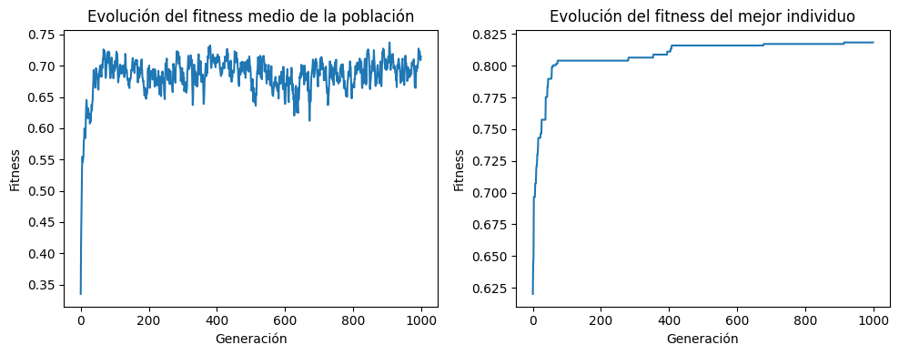

```python
generar_graficos_evolucion_fitness(ag_mejor_titanic)
generar_graficos_evolucion_fitness(ag_titanic_1000)
```

Vemos un comportamiento similar al del dataset `xor.csv`: en las primeras iteraciones el algoritmo consigue aumentar mucho el fitness tanto de la población como del mejor individuo, para después entrar a una llanura, hasta finalmente alcanzar un máximo en el que se estabiliza.

Como comentario general, se puede observar un comportamiento logarítmico.